# ДЗ Сентимент-анализ предложений с помощью линейных моделей

Проничкин Юрий

$$ Q = \frac{1}{l} \sum_{i = 1}^{l} log(1 + e^{-y_i(X_i, w)}) + \frac{1}{2}||w||^2 \dashrightarrow min $$

Значит градиент этой функции: $$ \nabla Q = \frac{1}{l} \sum_{i = 1}^{l} \frac{-y_iX_i}{1 + e^{y_i(X_i, w)}} + w $$

Здесь X - выборка из $l$ векторов размерности $n$, y - ответы на выборке X, w - вектор весов размерности $n$.

Импортируем нужные библиотеки

```python
import pandas as pd
from optimization import GDClassifier, SGDClassifier
import numpy as np
import scipy as sp
import matplotlib.pyplot as plt
import re
%matplotlib inline
```

Читаем тренировочные данные

```python
df = pd.read_csv('toxic_train.csv')
```

```python
y = np.array(df['is_toxic'], dtype=int)
```

```python
y = 2* y - 1
```

Функция для предобработки - убираем лишнее, приводим к нижнему регистру.

```python
def preprocessing(string):
    string = string.lower()
    string = re.sub('[^\w\s]', ' ', string)
    string = ' '.join(string.split('\n'))
    return string
```

Создаем разряженную матрицу - тренировочный датасет с помощью CountVectorizer

```python
corpus = list(df['comment_text'].map(preprocessing))
```

```python
from sklearn.feature_extraction.text import CountVectorizer
```

```python
vectorizer = CountVectorizer(min_df=4)
```

```python
X = vectorizer.fit_transform(corpus)
```

То же самое с тестовыми данными

```python
df = pd.read_csv('toxic_test.csv')
```

```python
y_test = np.array(df['is_toxic'], dtype=int)
y_test = y_test * 2 - 1
```

```python
corpus = list(df['comment_text'].map(preprocessing))
```

```python
X_test = vectorizer.transform(corpus)
```

Добавим константный признак

```python
X = sp.sparse.hstack((X, np.ones(X.shape[0])[:, None]))
```

```python
X_test = sp.sparse.hstack((X_test, np.ones(X_test.shape[0])[:, None]))
```

Проверим сходимость в зависимости от step_alpha, здесь step_beta=0, w_0=0

```python
alpha = np.logspace(-3, 2, 4)
to_drow = {}
```

```python
w_0 = np.zeros(X.shape[1])
```

```python
for step_alpha in alpha:
    gdc = GDClassifier('binary_logistic',
                    step_alpha=step_alpha,
                    step_beta=0,
                    l2_coef=1e-6)
    history = gdc.fit(X,
                  y,
                  w_0,
                  True,
                  X_test=X_test,
                  y_test=y_test)
    to_drow[f'{step_alpha}'] = history
```

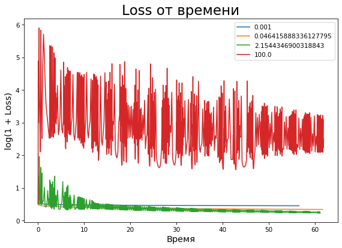

```python
plt.figure(figsize=(9,6), dpi=75)
for step_alpha in alpha:
    plt.plot(np.cumsum(to_drow[f'{step_alpha}']['time']), np.log1p(to_drow[f'{step_alpha}']['func']), label=f'{step_alpha}')
plt.xlabel('Время', fontsize=14)
plt.ylabel('log(1 + Loss)', fontsize=14)
plt.title('Loss от времени', fontsize=22)
plt.legend()
plt.show()
```

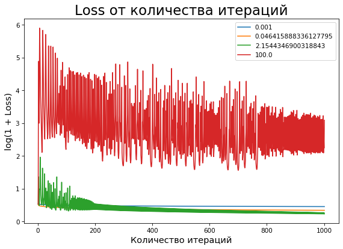

```python
plt.figure(figsize=(9,6), dpi=75)
for step_alpha in alpha:
    plt.plot(range(1, 1002), np.log1p(to_drow[f'{step_alpha}']['func']), label=f'{step_alpha}')
plt.xlabel('Количество итераций', fontsize=14)
plt.ylabel('log(1 + Loss)', fontsize=14)
plt.title('Loss от количества итераций', fontsize=22)
plt.legend()
plt.show()
```

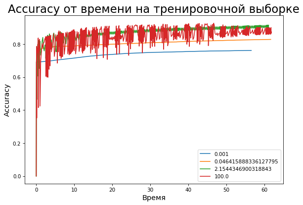

```python
plt.figure(figsize=(9,6), dpi=75)
for step_alpha in alpha:
    plt.plot(np.cumsum(to_drow[f'{step_alpha}']['time']), to_drow[f'{step_alpha}']['train_acc'], label=f'{step_alpha}')
plt.xlabel('Время', fontsize=14)
plt.ylabel('Accuracy', fontsize=14)
plt.title('Accuracy от времени на тренировочной выборке', fontsize=22)
plt.legend()
plt.show()
```

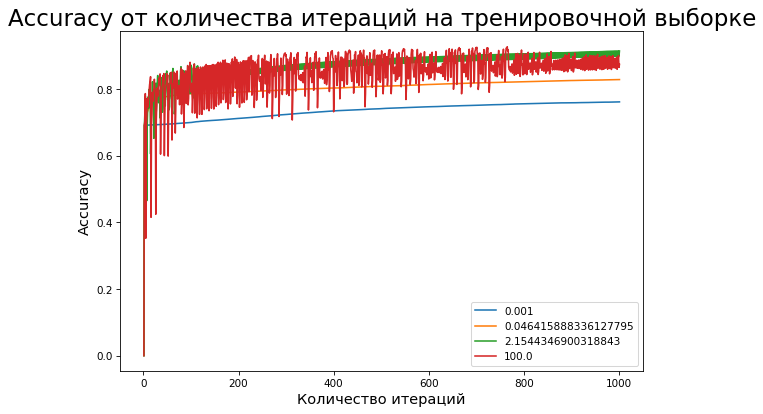

```python
plt.figure(figsize=(9,6), dpi=75)
for step_alpha in alpha:
    plt.plot(range(1, 1002), to_drow[f'{step_alpha}']['train_acc'], label=f'{step_alpha}')
plt.xlabel('Количество итераций', fontsize=14)
plt.ylabel('Accuracy', fontsize=14)
plt.title('Accuracy от количества итераций на тренировочной выборке', fontsize=22)
plt.legend()
plt.show()
```

В целом чем больше step_alpha тем быстрее сходится Градиентный спуск, при этом если взять его слилшком большим графики сильно осциллировать значит мы постоянно 'перепрыгиваем' через локальный минимум. В данной задаче кажется что при step_lapha ~ 0.1 метод будет сходится достаточно быстро при этом без осцилляций. Проверим:

```python
gdc = GDClassifier('binary_logistic',
                    step_alpha=0.1,
                    step_beta=0,
                    l2_coef=1e-6)
history = gdc.fit(X,
                  y,
                  w_0,
                  True,
                  X_test=X_test,
                  y_test=y_test)
```

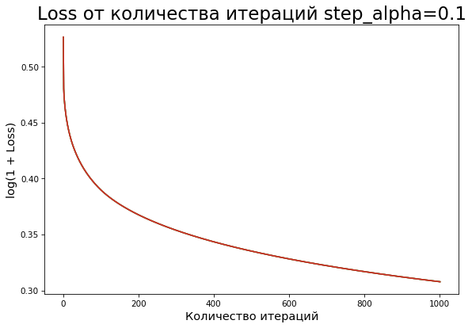

```python
plt.figure(figsize=(9,6), dpi=75)
for step_alpha in alpha:
    plt.plot(range(1, 1002), np.log1p(history['func']))
plt.xlabel('Количество итераций', fontsize=14)
plt.ylabel('log(1 + Loss)', fontsize=14)
plt.title('Loss от количества итераций step_alpha=0.1', fontsize=22)
plt.show()
```

```python
gdc = GDClassifier('binary_logistic',
                    step_alpha=0.1,
                    step_beta=0,
                    max_iter=5000,
                    l2_coef=1e-6)
history = gdc.fit(X,
                  y,
                  w_0,
                  True,
                  X_test=X_test,
                  y_test=y_test)
```

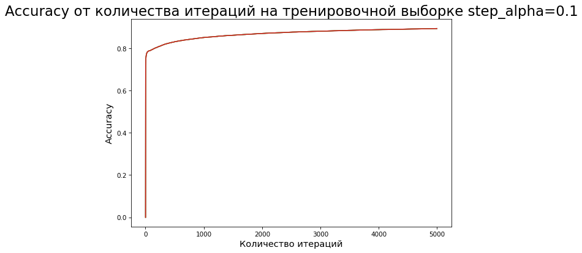

```python
plt.figure(figsize=(9,6), dpi=75)
for step_alpha in alpha:
    plt.plot(range(1, len(history['test_acc']) + 1), history['train_acc'])
plt.xlabel('Количество итераций', fontsize=14)
plt.ylabel('Accuracy', fontsize=14)
plt.title('Accuracy от количества итераций на тренировочной выборке step_alpha=0.1', fontsize=22)
plt.show()
```

```python
m_train = max(history['train_acc'])
print(f'Точность тренировочная: {m_train}')
```

```
Точность тренировочная: 0.8930101227406312
```

Теперь посмотрим на step_beta, при step_alpha = 0.1 и w_0 = 0

```python
to_drow = {}
beta = [0.01, 0.1, 0.5, 1, 10]
for step_beta in beta:
    gdc = GDClassifier('binary_logistic',
                    step_alpha=0.1,
                    step_beta=step_beta,
                    l2_coef=1e-6)
    history = gdc.fit(X,
                  y,
                  w_0,
                  True,
                  X_test=X_test,
                  y_test=y_test)
    to_drow[f'{step_beta}'] = history
```

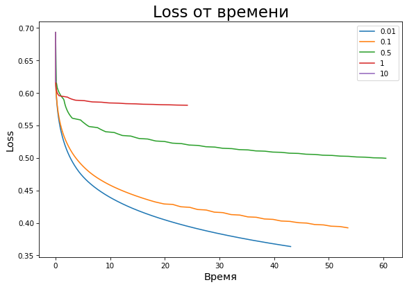

```python
plt.figure(figsize=(9,6), dpi=75)
for step_beta in beta:
    plt.plot(np.cumsum(to_drow[f'{step_beta}']['time']), to_drow[f'{step_beta}']['func'], label=f'{step_beta}')
plt.xlabel('Время', fontsize=14)
plt.ylabel('Loss', fontsize=14)
plt.title('Loss от времени', fontsize=22)
plt.legend()
plt.show()
```

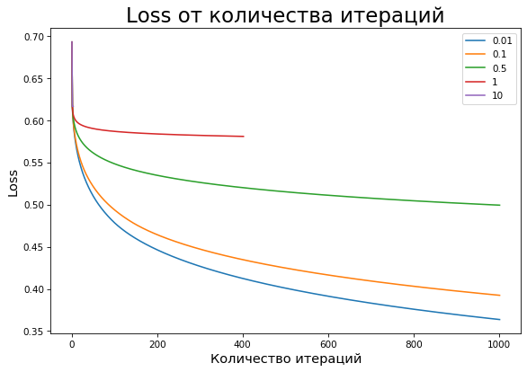

```python
plt.figure(figsize=(9,6), dpi=75)
for step_beta in beta:
    plt.plot(range(1, len(to_drow[f'{step_beta}']['func']) + 1), to_drow[f'{step_beta}']['func'], label=f'{step_beta}')
plt.xlabel('Количество итераций', fontsize=14)
plt.ylabel('Loss', fontsize=14)
plt.title('Loss от количества итераций', fontsize=22)
plt.legend()
plt.show()
```

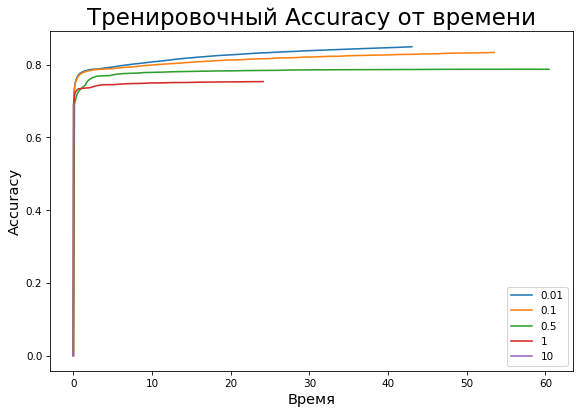

```python
plt.figure(figsize=(9,6), dpi=75)
for step_beta in beta:
    plt.plot(np.cumsum(to_drow[f'{step_beta}']['time']), to_drow[f'{step_beta}']['train_acc'], label=f'{step_beta}')
plt.xlabel('Время', fontsize=14)
plt.ylabel('Accuracy', fontsize=14)
plt.title('Тренировочный Accuracy от времени', fontsize=22)
plt.legend()
plt.show()
```

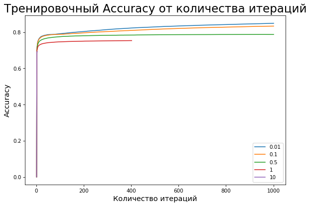

```python
plt.figure(figsize=(9,6), dpi=75)
for step_beta in beta:
    plt.plot(range(1, len(to_drow[f'{step_beta}']['func']) + 1), to_drow[f'{step_beta}']['train_acc'], label=f'{step_beta}')
plt.xlabel('Количество итераций', fontsize=14)
plt.ylabel('Accuracy', fontsize=14)
plt.title('Тренировочный Accuracy от количества итераций', fontsize=22)
plt.legend()
plt.show()
```

В целом чем меньше step_beta тем лучше сходится алгоритм при этом чем больше step_beta тем быстрее он останавливает сходимость, т.е. сходится быстрее.

Теперь посмотрим некоторые начальные приближения: два случайное на (0, 1), случайное на (-1, 1) из едениц, из 0.5

```python
W = [np.random.rand(X.shape[1]), np.random.rand(X.shape[1]) * 2 - 1, np.ones(X.shape[1]), np.ones(X.shape[1]) * 0.5, np.zeros(X.shape[1])]
```

```python
to_drow = {}
dict_i = {
    0: 'random 1',
    1: 'random 2',
    2: '1',
    3: '0.5',
    4: '0'
}
i = 0
for w in W:
    gdc = GDClassifier('binary_logistic',
                        step_alpha=0.1,
                        step_beta=0,
                        l2_coef=1e-6)
    history = gdc.fit(X,
                      y,
                      w,
                      True,
                      X_test=X_test,
                      y_test=y_test)
    to_drow[dict_i[i]] = history
    i += 1
```

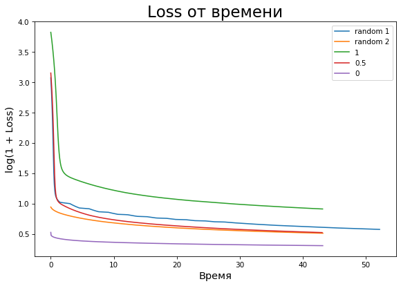

```python
plt.figure(figsize=(9,6), dpi=75)
for string in dict_i.values():
    plt.plot(np.cumsum(to_drow[string]['time']), np.log1p(to_drow[string]['func']), label=string)
plt.xlabel('Время', fontsize=14)
plt.ylabel('log(1 + Loss)', fontsize=14)
plt.title('Loss от времени', fontsize=22)
plt.legend()
plt.show()
```

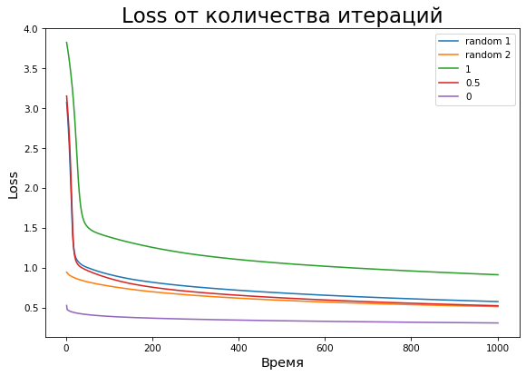

```python
plt.figure(figsize=(9,6), dpi=75)
for string in dict_i.values():
    plt.plot(range(1, 1002), np.log1p(to_drow[string]['func']), label=string)
plt.xlabel('Время', fontsize=14)
plt.ylabel('Loss', fontsize=14)
plt.title('Loss от количества итераций', fontsize=22)
plt.legend()
plt.show()
```

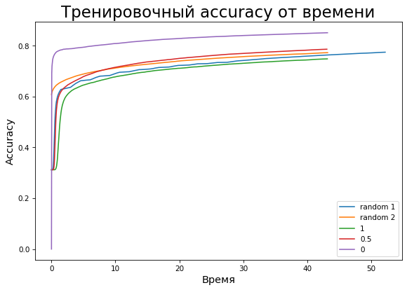

```python
plt.figure(figsize=(9,6), dpi=75)
for string in dict_i.values():
    plt.plot(np.cumsum(to_drow[string]['time']), to_drow[string]['train_acc'], label=string)
plt.xlabel('Время', fontsize=14)
plt.ylabel('Accuracy', fontsize=14)
plt.title('Тренировочный accuracy от времени', fontsize=22)
plt.legend()
plt.show()
```

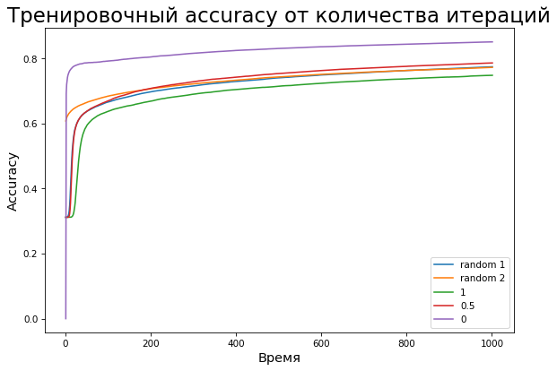

```python
plt.figure(figsize=(9,6), dpi=75)
for string in dict_i.values():
    plt.plot(range(1, 1002), to_drow[string]['train_acc'], label=string)
plt.xlabel('Время', fontsize=14)
plt.ylabel('Accuracy', fontsize=14)
plt.title('Тренировочный accuracy от количества итераций', fontsize=22)
plt.legend()
plt.show()
```

Очевидно что для данной задачи вектор из 0 ближе всего к локальному минимуму, поэтому и сходимость быстрее. Попробуем взять вектор близкий к 0.

```python
w = (np.random.rand(X.shape[1]) * 2 - 1) / 1e3
gdc = GDClassifier('binary_logistic',
                        step_alpha=0.1,
                        step_beta=0,
                        l2_coef=1e-6)
history = gdc.fit(X,
                      y,
                      w,
                      True,
                      X_test=X_test,
                      y_test=y_test)
```

```python
to_drow['small'] = history
```

```python
dict_i[5] = 'small'
```

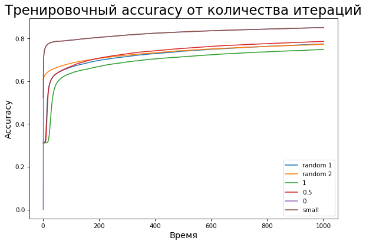

```python
plt.figure(figsize=(9,6), dpi=75)
for string in dict_i.values():
    plt.plot(range(1, 1002), to_drow[string]['train_acc'], label=string)
plt.xlabel('Время', fontsize=14)
plt.ylabel('Accuracy', fontsize=14)
plt.title('Тренировочный accuracy от количества итераций', fontsize=22)
plt.legend()
plt.show()
```

Сходимость не отличается от сходимости при начальном приближении 0.

Теперь пробуем SGD.

Оказалось что матрицы в координатном формате, а он не поддерживет сложное индксирование, переводим в csr.

```python
X = X.tocsr()
```

```python
X_test = X_test.tocsr()
```

```python
w_0 = np.zeros(X.shape[1])
```

```python
batch = [10, 100, 1000, 10000]
```

```python
to_drow = {}
for step_alpha in batch:
    sgd = SGDClassifier('binary_logistic',
                    batch_size=step_alpha,
                    step_alpha=0.1,
                    step_beta=0,
                    l2_coef=1e-6)
    history = sgd.fit(X,
                  y,
                  w_0,
                  True,
                  X_test=X_test,
                  y_test=y_test)
    to_drow[f'{step_alpha}'] = history
```

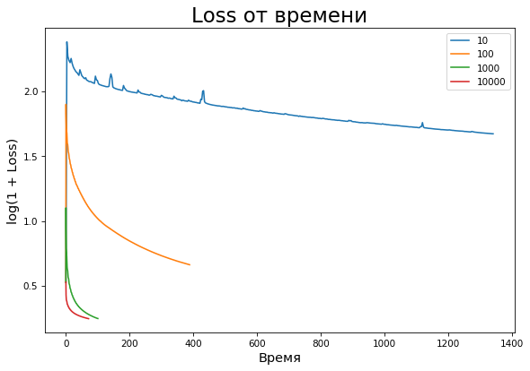

```python
plt.figure(figsize=(9,6), dpi=75)
for step_alpha in batch:
    plt.plot(np.cumsum(to_drow[f'{step_alpha}']['time']), np.log1p(to_drow[f'{step_alpha}']['func']), label=f'{step_alpha}')
plt.xlabel('Время', fontsize=14)
plt.ylabel('log(1 + Loss)', fontsize=14)
plt.title('Loss от времени', fontsize=22)
plt.legend()
plt.show()
```

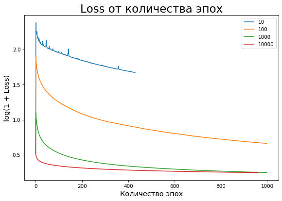

```python
plt.figure(figsize=(9,6), dpi=75)
for step_alpha in batch:
    plt.plot(to_drow[f'{step_alpha}']['epoch_num'], np.log1p(to_drow[f'{step_alpha}']['func']), label=f'{step_alpha}')
plt.xlabel('Количество эпох', fontsize=14)
plt.ylabel('log(1 + Loss)', fontsize=14)
plt.title('Loss от количества эпох', fontsize=22)
plt.legend()
plt.show()
```

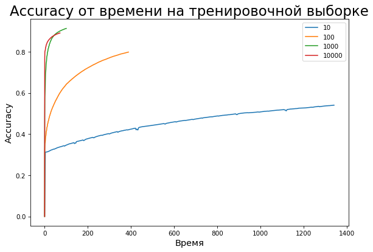

```python
plt.figure(figsize=(9,6), dpi=75)
for step_alpha in batch:
    plt.plot(np.cumsum(to_drow[f'{step_alpha}']['time']), to_drow[f'{step_alpha}']['train_acc'], label=f'{step_alpha}')
plt.xlabel('Время', fontsize=14)
plt.ylabel('Accuracy', fontsize=14)
plt.title('Accuracy от времени на тренировочной выборке', fontsize=22)
plt.legend()
plt.show()
```

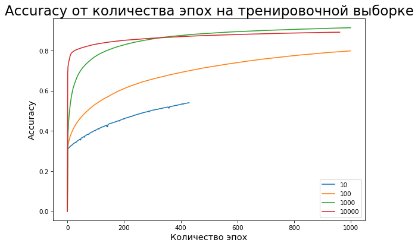

```python
plt.figure(figsize=(9,6), dpi=75)
for step_alpha in batch:
    plt.plot(to_drow[f'{step_alpha}']['epoch_num'], to_drow[f'{step_alpha}']['train_acc'], label=f'{step_alpha}')
plt.xlabel('Количество эпох', fontsize=14)
plt.ylabel('Accuracy', fontsize=14)
plt.title('Accuracy от количества эпох на тренировочной выборке', fontsize=22)
plt.legend()
plt.show()
```

```python
alpha = [0.001, 0.01, 0.1, 1, 10]
to_drow = {}
for step_alpha in alpha:
    sgd = SGDClassifier('binary_logistic',
                    batch_size=10000,
                    step_alpha=step_alpha,
                    step_beta=0,
                    l2_coef=1e-6)
    history = sgd.fit(X,
                  y,
                  w_0,
                  True,
                  X_test=X_test,
                  y_test=y_test)
    to_drow[f'{step_alpha}'] = history
```

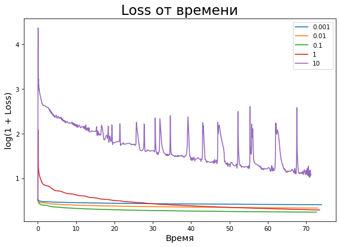

```python
plt.figure(figsize=(9,6), dpi=75)
for step_alpha in alpha:
    plt.plot(np.cumsum(to_drow[f'{step_alpha}']['time']), np.log1p(to_drow[f'{step_alpha}']['func']), label=f'{step_alpha}')
plt.xlabel('Время', fontsize=14)
plt.ylabel('log(1 + Loss)', fontsize=14)
plt.title('Loss от времени', fontsize=22)
plt.legend()
plt.show()
```

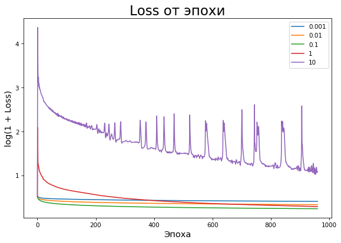

```python
plt.figure(figsize=(9,6), dpi=75)
for step_alpha in alpha:
    plt.plot(to_drow[f'{step_alpha}']['epoch_num'], np.log1p(to_drow[f'{step_alpha}']['func']), label=f'{step_alpha}')
plt.xlabel('Эпоха', fontsize=14)
plt.ylabel('log(1 + Loss)', fontsize=14)
plt.title('Loss от эпохи', fontsize=22)
plt.legend()
plt.show()
```

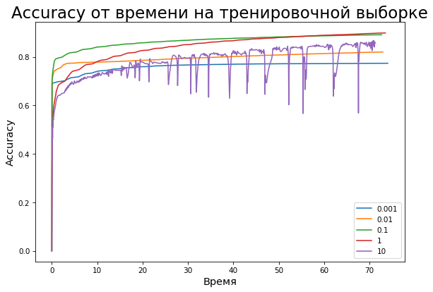

```python
plt.figure(figsize=(9,6), dpi=75)
for step_alpha in alpha:
    plt.plot(np.cumsum(to_drow[f'{step_alpha}']['time']), to_drow[f'{step_alpha}']['train_acc'], label=f'{step_alpha}')
plt.xlabel('Время', fontsize=14)
plt.ylabel('Accuracy', fontsize=14)
plt.title('Accuracy от времени на тренировочной выборке', fontsize=22)
plt.legend()
plt.show()
```

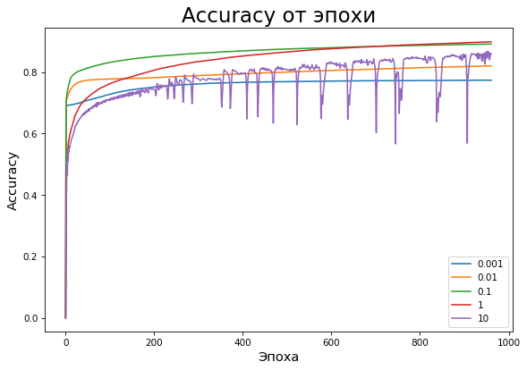

```python
plt.figure(figsize=(9,6), dpi=75)
for step_alpha in alpha:
    plt.plot(to_drow[f'{step_alpha}']['epoch_num'], to_drow[f'{step_alpha}']['train_acc'], label=f'{step_alpha}')
plt.xlabel('Эпоха', fontsize=14)
plt.ylabel('Accuracy', fontsize=14)
plt.title('Accuracy от эпохи', fontsize=22)
plt.legend()
plt.show()
```

Как и в обычном градиентном чем меньше step_alpha тем медленнее сходимость, при этм если параметр будет очень большим сходимость будет хуже

```python
beta = [0.001, 0.01, 0.1, 1, 10]
to_drow = {}
for step_alpha in beta:
    sgd = SGDClassifier('binary_logistic',
                    batch_size=10000,
                    step_alpha=0.1,
                    step_beta=step_alpha,
                    l2_coef=1e-6)
    history = sgd.fit(X,
                  y,
                  w_0,
                  True,
                  X_test=X_test,
                  y_test=y_test)
    to_drow[f'{step_alpha}'] = history
```

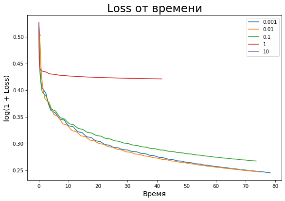

```python
plt.figure(figsize=(9,6), dpi=75)
for step_alpha in beta:
    plt.plot(np.cumsum(to_drow[f'{step_alpha}']['time']), np.log1p(to_drow[f'{step_alpha}']['func']), label=f'{step_alpha}')
plt.xlabel('Время', fontsize=14)
plt.ylabel('log(1 + Loss)', fontsize=14)
plt.title('Loss от времени', fontsize=22)
plt.legend()
plt.show()
```

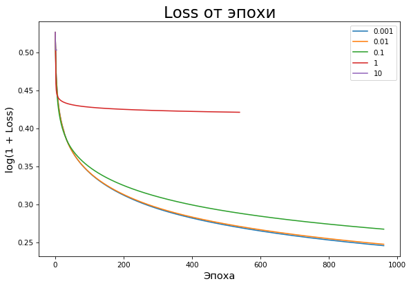

```python
plt.figure(figsize=(9,6), dpi=75)
for step_alpha in beta:
    plt.plot(to_drow[f'{step_alpha}']['epoch_num'], np.log1p(to_drow[f'{step_alpha}']['func']), label=f'{step_alpha}')
plt.xlabel('Эпоха', fontsize=14)
plt.ylabel('log(1 + Loss)', fontsize=14)
plt.title('Loss от эпохи', fontsize=22)
plt.legend()
plt.show()
```

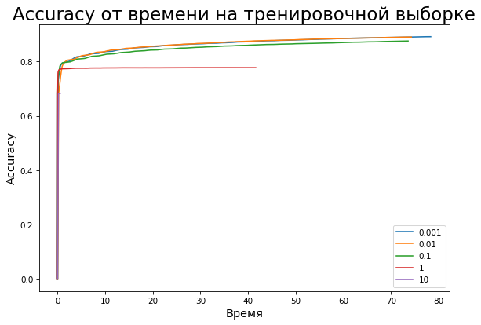

```python
plt.figure(figsize=(9,6), dpi=75)
for step_alpha in beta:
    plt.plot(np.cumsum(to_drow[f'{step_alpha}']['time']), to_drow[f'{step_alpha}']['train_acc'], label=f'{step_alpha}')
plt.xlabel('Время', fontsize=14)
plt.ylabel('Accuracy', fontsize=14)
plt.title('Accuracy от времени на тренировочной выборке', fontsize=22)
plt.legend()
plt.show()
```

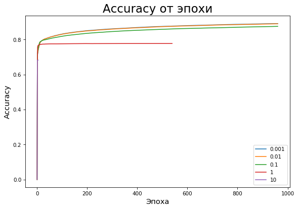

```python
plt.figure(figsize=(9,6), dpi=75)
for step_alpha in beta:
    plt.plot(to_drow[f'{step_alpha}']['epoch_num'], to_drow[f'{step_alpha}']['train_acc'], label=f'{step_alpha}')
plt.xlabel('Эпоха', fontsize=14)
plt.ylabel('Accuracy', fontsize=14)
plt.title('Accuracy от эпохи', fontsize=22)
plt.legend()
plt.show()
```

В целом так же как и в GDC чем меньше step_beta тем сходимость лучше, но дольше.

```python
W = [np.random.rand(X.shape[1]), np.random.rand(X.shape[1]) * 2 - 1, np.ones(X.shape[1]), np.ones(X.shape[1]) * 0.5, np.zeros(X.shape[1])]
to_drow = {}
dict_i = {
    0: 'random 1',
    1: 'random 2',
    2: '1',
    3: '0.5',
    4: '0'
}
i = 0
for w_0 in W:
    sgd = SGDClassifier('binary_logistic',
                    batch_size=1000,
                    step_alpha=0.1,
                    step_beta=0,
                    l2_coef=1e-6)
    history = sgd.fit(X,
                  y,
                  w_0,
                  True,
                  X_test=X_test,
                  y_test=y_test)
    to_drow[dict_i[i]] = history
    i += 1
```

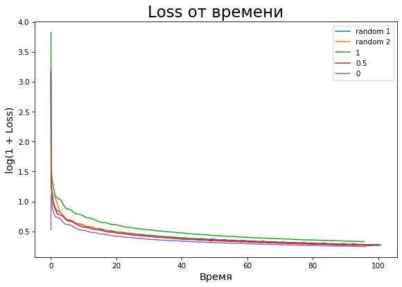

```python
plt.figure(figsize=(9,6), dpi=75)
for string in dict_i.values():
    plt.plot(np.cumsum(to_drow[string]['time']), np.log1p(to_drow[string]['func']), label=string)
plt.xlabel('Время', fontsize=14)
plt.ylabel('log(1 + Loss)', fontsize=14)
plt.title('Loss от времени', fontsize=22)
plt.legend()
plt.show()
```

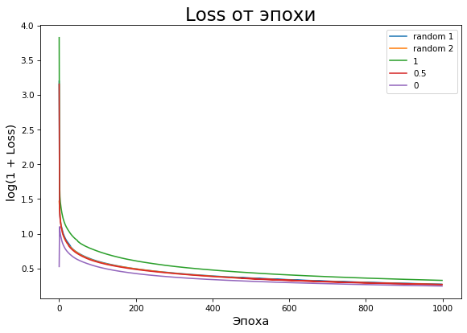

```python
plt.figure(figsize=(9,6), dpi=75)
for string in dict_i.values():
    plt.plot(to_drow[string]['epoch_num'], np.log1p(to_drow[string]['func']), label=string)
plt.xlabel('Эпоха', fontsize=14)
plt.ylabel('log(1 + Loss)', fontsize=14)
plt.title('Loss от эпохи', fontsize=22)
plt.legend()
plt.show()
```

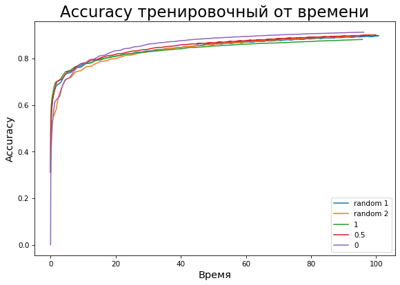

```python
plt.figure(figsize=(9,6), dpi=75)
for string in dict_i.values():
    plt.plot(np.cumsum(to_drow[string]['time']), to_drow[string]['train_acc'], label=string)
plt.xlabel('Время', fontsize=14)
plt.ylabel('Accuracy', fontsize=14)
plt.title('Accuracy тренировочный от времени', fontsize=22)
plt.legend()
plt.show()
```

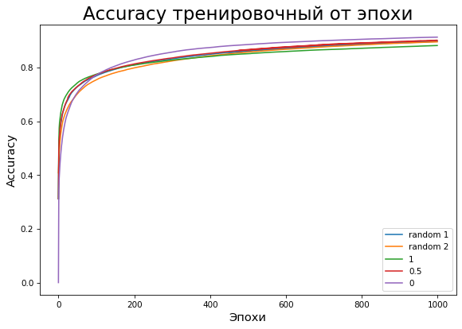

```python
plt.figure(figsize=(9,6), dpi=75)
for string in dict_i.values():
    plt.plot(to_drow[string]['epoch_num'], to_drow[string]['train_acc'], label=string)
plt.xlabel('Эпохи', fontsize=14)
plt.ylabel('Accuracy', fontsize=14)
plt.title('Accuracy тренировочный от эпохи', fontsize=22)
plt.legend()
plt.show()
```

Как и у GDC лучше всего подходит нулевой вектор.